# HW6

Che’ Cobb

October 2, 2018

```r
load(file = "N-MHSS-2015-DS0001-data-r.rda")
head(mh2015_puf)
```

```
##      CASEID    LST MHINTAKE MHDIAGEVAL MHREFERRAL TREATMT ADMINSERV
## 1 201500001 AL          Yes        Yes        Yes      No       Yes
## 2 201500002 AL          Yes        Yes        Yes      No       Yes
## 3 201500003 AL          Yes        Yes        Yes      No        No
## 4 201500004 AL          Yes        Yes        Yes      No        No
## 5 201500005 AL          Yes        Yes        Yes      No        No
## 6 201500006 AL          Yes        Yes        Yes     Yes       Yes
##   SETTINGIP SETTINGRC SETTINGDTPH SETTINGOP
## 1       Yes        No          No        No
## 2        No        No          No       Yes
## 3        No        No         Yes        No
## 4        No        No         Yes        No
## 5        No        No          No       Yes
## 6       Yes        No          No       Yes
##                                                FACILITYTYPE
```

[output cut: 167 more lines]

#### b. Please create code which lists the State abbreviations without their counts, one abbreviation per State value. It does not have to in data frame format. A vector is fine.

```
##  [1] "AL" "AK" "AZ" "AR" "CA" "CO" "CT" "DE" "FL" "GA" "HI" "ID" "IL" "IN"
## [15] "IA" "KS" "KY" "LA" "ME" "MD" "MA" "MI" "MN" "MS" "MO" "MT" "NE" "NV"
## [29] "NH" "NJ" "NM" "NY" "NC" "ND" "OH" "OK" "OR" "PA" "RI" "SC" "SD" "TN"
## [43] "TX" "UT" "VT" "VA" "WA" "WV" "WI" "WY"
```

#### c. Filter the data.frame from 1A. We are only interested in the Veterans Administration (VA) medical centers in the mainland United States-create a listing of counts of these centers by state, including only mainland locations. Alaska, Hawaii, and U.S. territories should be omitted. DC, while not a state, is in the mainland, so it should remain included. Convert this to data.frame()

```
##        CASEID    LST
## 123 201500123 AL
## 130 201500130 AL
## 131 201500131 AL
## 393 201500393 AZ
## 394 201500394 AZ
##                                                                       FACILITYTYPE
## 123 Veterans Administration medical center (VAMC) or other VA health care facility
## 130 Veterans Administration medical center (VAMC) or other VA health care facility
## 131 Veterans Administration medical center (VAMC) or other VA health care facility
## 393 Veterans Administration medical center (VAMC) or other VA health care facility
## 394 Veterans Administration medical center (VAMC) or other VA health care facility
```

#### d. Create a ggplot barchart of this filtered data set. Vary the bar’s colors by what State it has listed. Give it an appropriately professional title that is centered. Make sure you have informative axis labels. The State axis should be readable, not layered over each other. You’re welcome to have a legend or not.

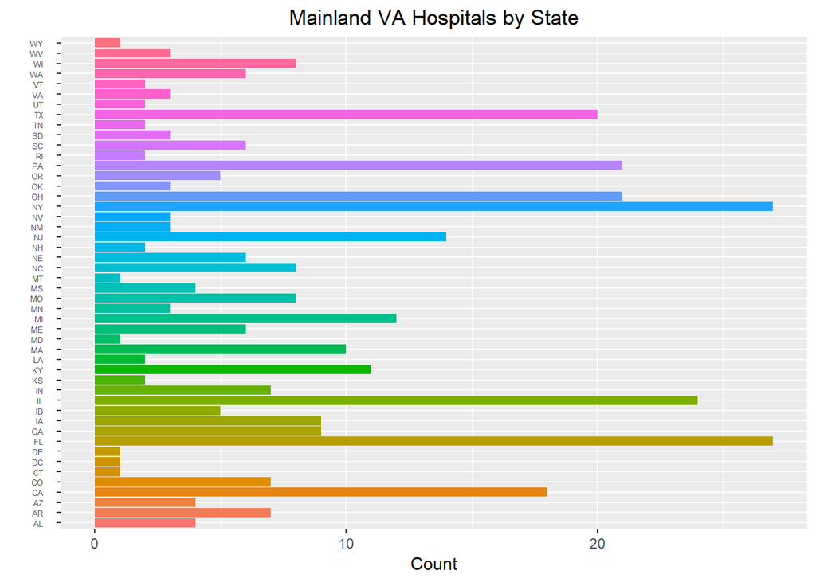

```r
ggplot(data =Filtered_VA,aes(x=LST, fill=LST)) +
labs(title="Mainland VA Hospitals by State", x = "", y="Count") +
geom_bar() +
coord_flip()+
theme(plot.title = element_text(hjust = .5),axis.text.y=element_text(size=5), legend.position="none")
```

## 2. Cleaning and Bringing in New Features (60%)

- **a. This graph (1D) might be somewhat misleading, as bigger states may have more hospitals, but could be more sparsely located. Read statesize.csv into your R environment. This contains essentially a vector of square miles for each state. In trying to merge it with your data.frame() from 1C, you find that they don’t match. Use paste() on your LST column in 1C to see what the matter is, and write what you observe in a comment**

```r
statesize <- read.csv('statesize.csv',header = T,sep = ",")
head(statesize)
```

```
##    StateName SqMiles Abbrev Region
## 1    Alabama   50750     AL  South
## 2     Alaska  570374     AK   West
## 3    Arizona  113642     AZ   West
## 4   Arkansas   52075     AR  South
## 5 California  155973     CA   West
## 6   Colorado  103730     CO   West
```

```r
paste(Filtered_VA$LST)
```

```
##   [1] "AL    " "AL    " "AL    " "AZ    " "AZ    " "AZ    " "AR    "
##   [8] "AR    " "AR    " "AR    " "AR    " "CA    " "CA    " "CA    "
##  [15] "CA    " "CA    " "CA    " "CA    " "CA    " "CA    " "CA    "
##  [22] "CA    " "CA    " "CA    " "CO    " "CO    " "CO    " "CO    "
##  [29] "CO    " "DE    " "FL    " "FL    " "FL    " "FL    " "FL    "
##  [36] "FL    " "FL    " "FL    " "FL    " "FL    " "FL    " "FL    "
##  [43] "FL    " "FL    " "FL    " "FL    " "FL    " "FL    " "FL    "
##  [50] "FL    " "FL    " "FL    " "GA    " "GA    " "GA    " "GA    "
##  [57] "GA    " "GA    " "GA    " "ID    " "ID    " "ID    " "ID    "
##  [64] "IL    " "IL    " "IL    " "IL    " "IL    " "IL    " "IL    "
##  [71] "IL    " "IL    " "IL    " "IL    " "IL    " "IL    " "IL    "
##  [78] "IL    " "IL    " "IL    " "IL    " "IL    " "IN    " "IN    "
##  [85] "IN    " "IN    " "IN    " "IN    " "IN    " "IA    " "IA    "
##  [92] "IA    " "IA    " "IA    " "IA    " "IA    " "IA    " "KS    "
##  [99] "KS    " "KY    " "KY    " "KY    " "KY    " "KY    " "KY    "
```

[output cut: 36 more lines]

There is trailing whitespace in the state abbrevations

- **b. Correct the problem with the LST column using any method in R that is programmatic and easily understandable. Once you have made these state abbreviations identical to statesize.csv’s Abbrev column, merge the data.frame() from 1C and statesize.csv in order to add size information**

```r
#trim the whitespace off abbrevations in filtered df
Filtered_VA$LST = gsub(' ','',Filtered_VA$LST)
#merge statesize and filterd df by Abbrev
mergedFiltered_VA<- merge(x= Filtered_VA, y=statesize, by.x = 'LST',by.y = 'Abbrev',all.x=TRUE)
# count the states frequency
mergedFiltered_VA[42,]
```

```
##    LST    CASEID
## 42  DC 201512699
##                                                                      FACILITYTYPE
## 42 Veterans Administration medical center (VAMC) or other VA health care facility
##    StateName SqMiles Region
## 42      <NA>      NA   <NA>
```

- **c. Calculate a new variable in your combined data.frame() which indicates the VA hospitals per thousand square miles**

```r
# count the states frequency
StateCount<-data.frame(table(mergedFiltered_VA$LST))
colnames(StateCount)<- c("Abbrev","Count")
StateCount
```

```
##    Abbrev Count
## 1      AL     4
## 2      AR     7
## 3      AZ     4
## 4      CA    18
## 5      CO     7
## 6      CT     1
## 7      DC     1
## 8      DE     1
## 9      FL    27
## 10     GA     9
## 11     IA     9
## 12     ID     5
## 13     IL    24
## 14     IN     7
```

[output cut: 34 more lines]

```r
# merge StateCount in to merfedFiltered datafram
mergedFiltered_VA<-merge(x=mergedFiltered_VA,y= StateCount,  by.x = 'LST',by.y = 'Abbrev',all.x=TRUE)
# 1000per sq miles = State Sq miles/stateCount
mergedFiltered_VA$VAPer1K<-(mergedFiltered_VA$Count/(mergedFiltered_VA$SqMiles/1000))
mergedFiltered_VA <-mergedFiltered_VA[!duplicated(mergedFiltered_VA$LST),]
head(mergedFiltered_VA)
```

```
##    LST    CASEID
## 1   AL 201500123
## 5   AR 201500819
## 12  AZ 201500394
## 16  CA 201501624
## 34  CO 201512696
## 41  CT 201512698
##                                                                      FACILITYTYPE
## 1  Veterans Administration medical center (VAMC) or other VA health care facility
## 5  Veterans Administration medical center (VAMC) or other VA health care facility
## 12 Veterans Administration medical center (VAMC) or other VA health care facility
## 16 Veterans Administration medical center (VAMC) or other VA health care facility
## 34 Veterans Administration medical center (VAMC) or other VA health care facility
## 41 Veterans Administration medical center (VAMC) or other VA health care facility
##      StateName SqMiles    Region Count    VAPer1K
## 1      Alabama   50750     South     4 0.07881773
## 5     Arkansas   52075     South     7 0.13442151
## 12     Arizona  113642      West     4 0.03519825
## 16  California  155973      West    18 0.11540459
## 34    Colorado  103730      West     7 0.06748289
## 41 Connecticut    4845 Northeast     1 0.20639835
```

##### d. Create another ggplot which considers the VAs per square thousand miles, rather than just frequency.

- **Make sure the State axis is readable, like before. Change the title and axes as appropriate.**
- **Modify the ggplot syntax to make your bars in descending order (there are StackOverflow topics for this, and I have demonstrated how in Live Coding in prior classes).**
- **Color-code the bars based on Region (see the merged data.frame)-however, change the color scheme from the default. Any set of colors is fine, so long as it is readable.**
- **Keep the legend-you should have four regions and therefore four colors. e. What patterns do you see? By this metric, is there any region that seems relatively high for VA medical centers per thousand square miles? How about low? Given these data, what advice might you give your boss before you start modeling (and why)?**

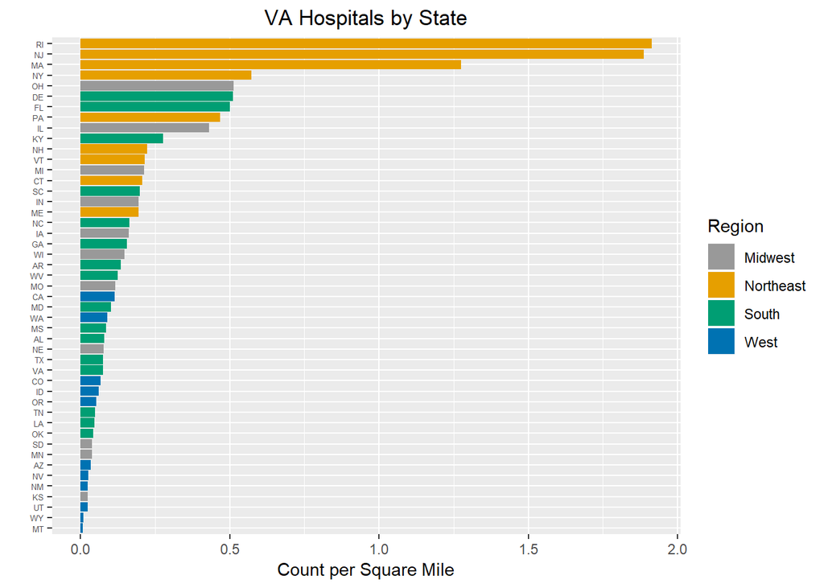

```r
# remove DC since it has NA values
mergedFiltered_VA <- subset(mergedFiltered_VA,mergedFiltered_VA$LST!='DC')


ggplot(data =mergedFiltered_VA, aes(x=reorder(LST, VAPer1K), VAPer1K, fill=Region)) +
labs(title="VA Hospitals by State", x = "", y="Count per Square Mile") +
geom_bar(stat="identity") +
scale_fill_manual(values = c("#999999", "#E69F00", "#009E73", "#0072B2")) +
coord_flip()+
theme(plot.title = element_text(hjust = 0.5),axis.text.y=element_text(size=5) )
```